# Ford GoBike System Data Exploration

## Introduction

> This document explores a dataset which includes information about individual rides made in a bike-sharing system covering the greater San Francisco Bay area.

## Preliminary Wrangling

```python
# import all packages and set plots to be embedded inline
import numpy as np
import pandas as pd
import matplotlib.pyplot as plt
import seaborn as sb
import zipfile
import os
import glob

%matplotlib inline
```

> Load in your dataset and describe its properties through the questions below. Try and motivate your exploration goals through this section.

```python
# Load dataset into a pandas dataframe
bike = pd.read_csv('201902-fordgobike-tripdata.csv')

# High-level overview of data shape and composition
print(bike.shape, "\n")
print(bike.dtypes, "\n")
bike.head()
```

```
(183412, 16)

duration_sec                 int64
start_time                  object
end_time                    object
start_station_id           float64
start_station_name          object
start_station_latitude     float64
start_station_longitude    float64
end_station_id             float64
end_station_name            object
end_station_latitude       float64
end_station_longitude      float64
bike_id                      int64
user_type                   object
member_birth_year          float64
member_gender               object
bike_share_for_all_trip     object
dtype: object
```

|  | duration_sec | start_time | end_time | start_station_id | start_station_name | start_station_latitude | start_station_longitude | end_station_id | end_station_name | end_station_latitude | end_station_longitude | bike_id | user_type | member_birth_year | member_gender | bike_share_for_all_trip |
| --- | --- | --- | --- | --- | --- | --- | --- | --- | --- | --- | --- | --- | --- | --- | --- | --- |
| 0 | 52185 | 2019-02-28 17:32:10.1450 | 2019-03-01 08:01:55.9750 | 21.0 | Montgomery St BART Station (Market St at 2nd St) | 37.789625 | -122.400811 | 13.0 | Commercial St at Montgomery St | 37.794231 | -122.402923 | 4902 | Customer | 1984.0 | Male | No |
| 1 | 42521 | 2019-02-28 18:53:21.7890 | 2019-03-01 06:42:03.0560 | 23.0 | The Embarcadero at Steuart St | 37.791464 | -122.391034 | 81.0 | Berry St at 4th St | 37.775880 | -122.393170 | 2535 | Customer | NaN | NaN | No |
| 2 | 61854 | 2019-02-28 12:13:13.2180 | 2019-03-01 05:24:08.1460 | 86.0 | Market St at Dolores St | 37.769305 | -122.426826 | 3.0 | Powell St BART Station (Market St at 4th St) | 37.786375 | -122.404904 | 5905 | Customer | 1972.0 | Male | No |
| 3 | 36490 | 2019-02-28 17:54:26.0100 | 2019-03-01 04:02:36.8420 | 375.0 | Grove St at Masonic Ave | 37.774836 | -122.446546 | 70.0 | Central Ave at Fell St | 37.773311 | -122.444293 | 6638 | Subscriber | 1989.0 | Other | No |
| 4 | 1585 | 2019-02-28 23:54:18.5490 | 2019-03-01 00:20:44.0740 | 7.0 | Frank H Ogawa Plaza | 37.804562 | -122.271738 | 222.0 | 10th Ave at E 15th St | 37.792714 | -122.248780 | 4898 | Subscriber | 1974.0 | Male | Yes |

```python
bike.info()
```

```
<class 'pandas.core.frame.DataFrame'>
RangeIndex: 183412 entries, 0 to 183411
Data columns (total 16 columns):
 #   Column                   Non-Null Count   Dtype
---  ------                   --------------   -----
 0   duration_sec             183412 non-null  int64
 1   start_time               183412 non-null  object
 2   end_time                 183412 non-null  object
 3   start_station_id         183215 non-null  float64
 4   start_station_name       183215 non-null  object
 5   start_station_latitude   183412 non-null  float64
 6   start_station_longitude  183412 non-null  float64
 7   end_station_id           183215 non-null  float64
 8   end_station_name         183215 non-null  object
 9   end_station_latitude     183412 non-null  float64
 10  end_station_longitude    183412 non-null  float64
 11  bike_id                  183412 non-null  int64
 12  user_type                183412 non-null  object
 13  member_birth_year        175147 non-null  float64
 14  member_gender            175147 non-null  object
 15  bike_share_for_all_trip  183412 non-null  object
dtypes: float64(7), int64(2), object(7)
memory usage: 22.4+ MB
```

```python
bike.describe()
```

|  | duration_sec | start_station_id | start_station_latitude | start_station_longitude | end_station_id | end_station_latitude | end_station_longitude | bike_id | member_birth_year |
| --- | --- | --- | --- | --- | --- | --- | --- | --- | --- |
| count | 183412.000000 | 183215.000000 | 183412.000000 | 183412.000000 | 183215.000000 | 183412.000000 | 183412.000000 | 183412.000000 | 175147.000000 |
| mean | 726.078435 | 138.590427 | 37.771223 | -122.352664 | 136.249123 | 37.771427 | -122.352250 | 4472.906375 | 1984.806437 |
| std | 1794.389780 | 111.778864 | 0.099581 | 0.117097 | 111.515131 | 0.099490 | 0.116673 | 1664.383394 | 10.116689 |
| min | 61.000000 | 3.000000 | 37.317298 | -122.453704 | 3.000000 | 37.317298 | -122.453704 | 11.000000 | 1878.000000 |
| 25% | 325.000000 | 47.000000 | 37.770083 | -122.412408 | 44.000000 | 37.770407 | -122.411726 | 3777.000000 | 1980.000000 |
| 50% | 514.000000 | 104.000000 | 37.780760 | -122.398285 | 100.000000 | 37.781010 | -122.398279 | 4958.000000 | 1987.000000 |
| 75% | 796.000000 | 239.000000 | 37.797280 | -122.286533 | 235.000000 | 37.797320 | -122.288045 | 5502.000000 | 1992.000000 |
| max | 85444.000000 | 398.000000 | 37.880222 | -121.874119 | 398.000000 | 37.880222 | -121.874119 | 6645.000000 | 2001.000000 |

## What is the structure of your dataset?

> There are 183412 trips taken during the month of February 2019 in the dataset with 16 features (duration_sec, start_time, end_time, start_station_id, start_station_name, start_station_latitude, start_station_longitude, end_station_id, end_station_name, end_station_latitude, end_station_longitude, bike_id, user_type, member_birth_year, member_gender, bike_share_for_all_trip). The features consists of different types (ints, floats, strings, datetime, and categorical variables.

> integers: ['duration_sec']

> floats: ['start_station_latitude', 'start_station_longitude', 'end_station_latitude', 'end_station_longitude']

> strings: ['start_station_id', 'start_station_name', 'end_station_id', 'end_station_name', 'bike_id']

> datetime: ['start_time', 'end_time']

> categorical: ['user_type', 'member_gender', 'bike_share_for_all_trip']

### What is/are the main feature(s) of interest in your dataset?

> I am interested in finding out the features that affect ride duration and the number of trips taken per day, month, and year.

### What features in the dataset do you think will help support your investigation into your feature(s) of interest?

> I am proceeding with the assumption that the distance between the start_station and end_station location will have strong effect on the duration of the ride. I also think that age of the members, user_type, member_gender also determines the number of rides taken.

## Additional Data Wrangling

In this section we will be:

> - gathering additional data for the remaining months of the year
> - exploring the dataset and cleaning issues found within
> - deriving additional columns that support our analysis

```python
# Ford GoBike System Data for the months of January, March, and April was downloaded in zip format and stored in the 'ford-gobike' folder
folder = 'ford-gobike'

# extracting the zipped files using the zipfile module.
if not os.path.exists('ford_jan_apr.csv'):
    for file in os.listdir(folder):
        with zipfile.ZipFile(os.path.join(folder, file)) as myzip:
            myzip.extractall()
```

```python
'''
# using pandas concat method to combine all the csv files located in the 'ford_jan_apr' folder including data for the month of February
jan_apr = pd.concat(map(pd.read_csv, glob.glob('ford_jan_apr' + "/*.csv")))

#saving the combined dataset to the local machine
jan_apr.to_csv('ford_jan_apr.csv', index=False)
'''
```

```
'\n# using pandas concat method to combine all the csv files located in the \'ford_jan_apr\' folder including data for the month of February\njan_apr = pd.concat(map(pd.read_csv, glob.glob(\'ford_jan_apr\' + "/*.csv")))\n\n#saving the combined dataset to the local machine\njan_apr.to_csv(\'ford_jan_…
```

```python
#loading the saved csv file into a pandas dataframe
ford_jan_apr = pd.read_csv('ford_jan_apr.csv')

# displaying the first 6 rows of the dataset
ford_jan_apr.head()
```

|  | duration_sec | start_time | end_time | start_station_id | start_station_name | start_station_latitude | start_station_longitude | end_station_id | end_station_name | end_station_latitude | end_station_longitude | bike_id | user_type | member_birth_year | member_gender | bike_share_for_all_trip |
| --- | --- | --- | --- | --- | --- | --- | --- | --- | --- | --- | --- | --- | --- | --- | --- | --- |
| 0 | 80825 | 2019-01-31 17:57:44.6130 | 2019-02-01 16:24:49.8640 | 229.0 | Foothill Blvd at 42nd Ave | 37.775745 | -122.213037 | 196.0 | Grand Ave at Perkins St | 37.808894 | -122.256460 | 4861 | Subscriber | 1989.0 | Male | No |
| 1 | 65900 | 2019-01-31 20:58:33.8860 | 2019-02-01 15:16:54.1730 | 4.0 | Cyril Magnin St at Ellis St | 37.785881 | -122.408915 | 134.0 | Valencia St at 24th St | 37.752428 | -122.420628 | 5506 | Subscriber | 1989.0 | Male | No |
| 2 | 62633 | 2019-01-31 18:06:52.9240 | 2019-02-01 11:30:46.5300 | 245.0 | Downtown Berkeley BART | 37.870139 | -122.268422 | 157.0 | 65th St at Hollis St | 37.846784 | -122.291376 | 2717 | Customer | 1965.0 | Female | No |
| 3 | 44680 | 2019-01-31 19:46:09.7190 | 2019-02-01 08:10:50.3180 | 85.0 | Church St at Duboce Ave | 37.770083 | -122.429156 | 53.0 | Grove St at Divisadero | 37.775946 | -122.437777 | 4557 | Customer | 1974.0 | Male | No |
| 4 | 60709 | 2019-01-31 14:19:01.5410 | 2019-02-01 07:10:51.0650 | 16.0 | Steuart St at Market St | 37.794130 | -122.394430 | 28.0 | The Embarcadero at Bryant St | 37.787168 | -122.388098 | 2100 | Customer | NaN | NaN | No |

```python
# dimension of the combined january to april dataset
ford_jan_apr.shape
```

```
(870904, 16)
```

```python
# displaying the data types of each feature
ford_jan_apr.dtypes
```

```
duration_sec                 int64
start_time                  object
end_time                    object
start_station_id           float64
start_station_name          object
start_station_latitude     float64
start_station_longitude    float64
end_station_id             float64
end_station_name            object
end_station_latitude       float64
end_station_longitude      float64
bike_id                      int64
user_type                   object
member_birth_year          float64
member_gender               object
bike_share_for_all_trip     object
dtype: object
```

```python
#printing dataset information
ford_jan_apr.info()
```

```
<class 'pandas.core.frame.DataFrame'>
RangeIndex: 870904 entries, 0 to 870903
Data columns (total 16 columns):
 #   Column                   Non-Null Count   Dtype
---  ------                   --------------   -----
 0   duration_sec             870904 non-null  int64
 1   start_time               870904 non-null  object
 2   end_time                 870904 non-null  object
 3   start_station_id         870174 non-null  float64
 4   start_station_name       870174 non-null  object
 5   start_station_latitude   870904 non-null  float64
 6   start_station_longitude  870904 non-null  float64
 7   end_station_id           870174 non-null  float64
 8   end_station_name         870174 non-null  object
 9   end_station_latitude     870904 non-null  float64
 10  end_station_longitude    870904 non-null  float64
 11  bike_id                  870904 non-null  int64
 12  user_type                870904 non-null  object
 13  member_birth_year        829997 non-null  float64
 14  member_gender            830000 non-null  object
 15  bike_share_for_all_trip  870904 non-null  object
dtypes: float64(7), int64(2), object(7)
memory usage: 106.3+ MB
```

```python
# looking at 30 random trips from the dataset
#ford_jan_apr.sample(30)
```

```python
#columns to convert to datetime object
cols_date = ['start_time', 'end_time']

#function to convert columns of a dataframe to datetime object
def date_time(df, cols):
    ''' The function takes as input a dataframe and a list of columns to convert. '''
    for col in cols:
        df[col] = pd.to_datetime(df[col])

#function call to convert dataframe columns to datetime object
date_time(ford_jan_apr, cols_date)

#list of columns to convert to category type
cat_cols = ['user_type', 'member_gender', 'bike_share_for_all_trip']

#function to convert columns of a dataframe to any type
def to_type(df, cols, d_type='str'):
    ''' The function takes as input a dataframe, a list of columns and the keyword argument d_type which specifies the type to convert to. '''
    for col in cols:
        df[col] = df[col].astype(d_type)

#function call to convert list of colulmns to category type
to_type(ford_jan_apr, cat_cols, d_type='category')

#list of columns to convert to string typ
str_cols = ['start_station_id', 'end_station_id', 'bike_id']

#function call to convert list of columns to string.
to_type(ford_jan_apr, str_cols)
```

```python
# checking for duplicates rides
ford_jan_apr[ford_jan_apr.index.duplicated()]
```

|  | duration_sec | start_time | end_time | start_station_id | start_station_name | start_station_latitude | start_station_longitude | end_station_id | end_station_name | end_station_latitude | end_station_longitude | bike_id | user_type | member_birth_year | member_gender | bike_share_for_all_trip |
| --- | --- | --- | --- | --- | --- | --- | --- | --- | --- | --- | --- | --- | --- | --- | --- | --- |

```python
# verifying the accuracy of duration_sec values
total_seconds = ford_jan_apr.end_time - ford_jan_apr.start_time
total_seconds = total_seconds.dt.total_seconds().astype('int')

# number of rides vs the number of rides with accurate duration_sec values
print(ford_jan_apr.shape[0], (total_seconds == ford_jan_apr.duration_sec).sum())
```

```
870904 870891
```

```python
# assigning total_seconds to the duration_sec column
ford_jan_apr['duration_sec'] = total_seconds
```

```python
# checking the number of rides with accurate duration_sec values
print(ford_jan_apr.shape[0], (total_seconds == ford_jan_apr.duration_sec).sum())
```

```
870904 870904
```

```python
# adding a new column called age to the dataframe by subtracting member_birth_year from start_time
ford_jan_apr['age'] = ford_jan_apr['start_time'].dt.year - ford_jan_apr['member_birth_year']

# replacing NaN values in the age column with the average age of members
mean_age = ford_jan_apr['age'].mean()
ford_jan_apr['age'].fillna(mean_age, inplace=True)

# converting the age column to int type
to_type(ford_jan_apr, ['age'], d_type='int')
```

```python
#verifying that the age column has been converted to an integer
assert ford_jan_apr.age.dtype == 'int'
```

```python
ford_jan_apr.head()
```

|  | duration_sec | start_time | end_time | start_station_id | start_station_name | start_station_latitude | start_station_longitude | end_station_id | end_station_name | end_station_latitude | end_station_longitude | bike_id | user_type | member_birth_year | member_gender | bike_share_for_all_trip | age |
| --- | --- | --- | --- | --- | --- | --- | --- | --- | --- | --- | --- | --- | --- | --- | --- | --- | --- |
| 0 | 80825 | 2019-01-31 17:57:44.613 | 2019-02-01 16:24:49.864 | 229.0 | Foothill Blvd at 42nd Ave | 37.775745 | -122.213037 | 196.0 | Grand Ave at Perkins St | 37.808894 | -122.256460 | 4861 | Subscriber | 1989.0 | Male | No | 30 |
| 1 | 65900 | 2019-01-31 20:58:33.886 | 2019-02-01 15:16:54.173 | 4.0 | Cyril Magnin St at Ellis St | 37.785881 | -122.408915 | 134.0 | Valencia St at 24th St | 37.752428 | -122.420628 | 5506 | Subscriber | 1989.0 | Male | No | 30 |
| 2 | 62633 | 2019-01-31 18:06:52.924 | 2019-02-01 11:30:46.530 | 245.0 | Downtown Berkeley BART | 37.870139 | -122.268422 | 157.0 | 65th St at Hollis St | 37.846784 | -122.291376 | 2717 | Customer | 1965.0 | Female | No | 54 |
| 3 | 44680 | 2019-01-31 19:46:09.719 | 2019-02-01 08:10:50.318 | 85.0 | Church St at Duboce Ave | 37.770083 | -122.429156 | 53.0 | Grove St at Divisadero | 37.775946 | -122.437777 | 4557 | Customer | 1974.0 | Male | No | 45 |
| 4 | 60709 | 2019-01-31 14:19:01.541 | 2019-02-01 07:10:51.065 | 16.0 | Steuart St at Market St | 37.794130 | -122.394430 | 28.0 | The Embarcadero at Bryant St | 37.787168 | -122.388098 | 2100 | Customer | NaN | NaN | No | 34 |

```python
#importing modules from the math package
from math import sin, cos, sqrt, atan2, radians

#function to calculate distance between two geographical locations using their latitude and longitude
def calculateDistance(row, lat1, lat2, lon1, lon2):
    lat_start = row[lat1]
    lat_end = row[lat2]
    lon_start = row[lon1]
    lon_end = row[lon2]
    R = 6373.0 # approximate radius of earth in km
    dlon = radians(lon_end - lon_start)
    dlat = radians(lat_end - lat_start)
    a = sin(dlat / 2)**2 + cos(lat_start) * cos(lat_end) * sin(dlon / 2)**2
    c = 2 * atan2(sqrt(a), sqrt(1 - a))

    d = R * c
    return d

cols = []
ford_jan_apr['distance'] = ford_jan_apr.apply(lambda row: calculateDistance(row, 'start_station_latitude', 'end_station_latitude', 'start_station_longitude', 'end_station_longitude'), axis=1)
```

```python
ford_jan_apr.head()
```

|  | duration_sec | start_time | end_time | start_station_id | start_station_name | start_station_latitude | start_station_longitude | end_station_id | end_station_name | end_station_latitude | end_station_longitude | bike_id | user_type | member_birth_year | member_gender | bike_share_for_all_trip | age | distance |
| --- | --- | --- | --- | --- | --- | --- | --- | --- | --- | --- | --- | --- | --- | --- | --- | --- | --- | --- |
| 0 | 80825 | 2019-01-31 17:57:44.613 | 2019-02-01 16:24:49.864 | 229.0 | Foothill Blvd at 42nd Ave | 37.775745 | -122.213037 | 196.0 | Grand Ave at Perkins St | 37.808894 | -122.256460 | 4861 | Subscriber | 1989.0 | Male | No | 30 | 6.059263 |
| 1 | 65900 | 2019-01-31 20:58:33.886 | 2019-02-01 15:16:54.173 | 4.0 | Cyril Magnin St at Ellis St | 37.785881 | -122.408915 | 134.0 | Valencia St at 24th St | 37.752428 | -122.420628 | 5506 | Subscriber | 1989.0 | Male | No | 30 | 3.941322 |
| 2 | 62633 | 2019-01-31 18:06:52.924 | 2019-02-01 11:30:46.530 | 245.0 | Downtown Berkeley BART | 37.870139 | -122.268422 | 157.0 | 65th St at Hollis St | 37.846784 | -122.291376 | 2717 | Customer | 1965.0 | Female | No | 54 | 3.619671 |
| 3 | 44680 | 2019-01-31 19:46:09.719 | 2019-02-01 08:10:50.318 | 85.0 | Church St at Duboce Ave | 37.770083 | -122.429156 | 53.0 | Grove St at Divisadero | 37.775946 | -122.437777 | 4557 | Customer | 1974.0 | Male | No | 45 | 1.157555 |
| 4 | 60709 | 2019-01-31 14:19:01.541 | 2019-02-01 07:10:51.065 | 16.0 | Steuart St at Market St | 37.794130 | -122.394430 | 28.0 | The Embarcadero at Bryant St | 37.787168 | -122.388098 | 2100 | Customer | NaN | NaN | No | 34 | 1.044785 |

```python
# extracting the day_of _week and month name from the start_time column using datetime functions and storing them in new columns
ford_jan_apr['day_of_week'] = ford_jan_apr['start_time'].dt.day_name()

#converting the day_of_week column to a categorical variable
ford_jan_apr['day_of_week'] = pd.Categorical(ford_jan_apr['day_of_week'] , categories=['Monday','Tuesday','Wednesday','Thursday','Friday','Saturday', 'Sunday'],ordered=True)

ford_jan_apr['month'] = ford_jan_apr['start_time'].dt.month_name()

#converting the month column to a categorical variable
ford_jan_apr['month'] = pd.Categorical(ford_jan_apr['month'] , categories=['January','February', 'March', 'April'], ordered=True)
```

```python
# function to calculate time of day
def time_day(time):
    if time.hour >= 12 and time.hour <= 16:
        return 'Afternoon'
    elif time.hour > 16 and time.hour <= 19:
        return "Evening"
    elif time.hour > 19 and time.hour <= 24:
        return "Night"
    else:
        return 'Morning'


# adding a new column called 'time_of_day' to the dataframe by applying the time_day() function to the 'start_time' column
ford_jan_apr['time_of_day'] = ford_jan_apr['start_time'].apply(lambda row: time_day(row))

#converting the time_of_day column to a categorical variable
ford_jan_apr['time_of_day'] = pd.Categorical(ford_jan_apr['time_of_day'] , categories=['Morning','Afternoon','Evening','Night'],ordered=True)
```

```python
ford_jan_apr.info()
```

```
<class 'pandas.core.frame.DataFrame'>
RangeIndex: 870904 entries, 0 to 870903
Data columns (total 21 columns):
 #   Column                   Non-Null Count   Dtype
---  ------                   --------------   -----
 0   duration_sec             870904 non-null  int32
 1   start_time               870904 non-null  datetime64[ns]
 2   end_time                 870904 non-null  datetime64[ns]
 3   start_station_id         870904 non-null  object
 4   start_station_name       870174 non-null  object
 5   start_station_latitude   870904 non-null  float64
 6   start_station_longitude  870904 non-null  float64
 7   end_station_id           870904 non-null  object
 8   end_station_name         870174 non-null  object
 9   end_station_latitude     870904 non-null  float64
 10  end_station_longitude    870904 non-null  float64
 11  bike_id                  870904 non-null  object
 12  user_type                870904 non-null  category
 13  member_birth_year        829997 non-null  float64
 14  member_gender            830000 non-null  category
 15  bike_share_for_all_trip  870904 non-null  category
 16  age                      870904 non-null  int32
 17  distance                 870904 non-null  float64
 18  day_of_week              870904 non-null  category
 19  month                    870904 non-null  category
 20  time_of_day              870904 non-null  category
dtypes: category(6), datetime64[ns](2), float64(6), int32(2), object(5)
memory usage: 98.0+ MB
```

```python
# checking for missing values
ford_jan_apr.isna().sum()
```

```
duration_sec                   0
start_time                     0
end_time                       0
start_station_id               0
start_station_name           730
start_station_latitude         0
start_station_longitude        0
end_station_id                 0
end_station_name             730
end_station_latitude           0
end_station_longitude          0
bike_id                        0
user_type                      0
member_birth_year          40907
member_gender              40904
bike_share_for_all_trip        0
age                            0
distance                       0
day_of_week                    0
month                          0
time_of_day                    0
dtype: int64
```

```python
# number of unique gender types for Ford GoBike Members
ford_jan_apr['member_gender'].nunique()
```

```
3
```

```python
# Ford GoBike members unique gender types
ford_jan_apr['member_gender'].unique()
```

```
['Male', 'Female', NaN, 'Other']
Categories (3, object): ['Female', 'Male', 'Other']
```

```python
# dropping columns that are not required for our analysis
master = ford_jan_apr.drop(columns=['start_station_latitude', 'start_station_longitude', 'end_station_latitude', 'end_station_longitude', 'bike_share_for_all_trip'], axis=1)

master.info()
```

```
<class 'pandas.core.frame.DataFrame'>
RangeIndex: 870904 entries, 0 to 870903
Data columns (total 16 columns):
 #   Column              Non-Null Count   Dtype
---  ------              --------------   -----
 0   duration_sec        870904 non-null  int32
 1   start_time          870904 non-null  datetime64[ns]
 2   end_time            870904 non-null  datetime64[ns]
 3   start_station_id    870904 non-null  object
 4   start_station_name  870174 non-null  object
 5   end_station_id      870904 non-null  object
 6   end_station_name    870174 non-null  object
 7   bike_id             870904 non-null  object
 8   user_type           870904 non-null  category
 9   member_birth_year   829997 non-null  float64
 10  member_gender       830000 non-null  category
 11  age                 870904 non-null  int32
 12  distance            870904 non-null  float64
 13  day_of_week         870904 non-null  category
 14  month               870904 non-null  category
 15  time_of_day         870904 non-null  category
dtypes: category(5), datetime64[ns](2), float64(2), int32(2), object(5)
memory usage: 70.6+ MB
```

```python
#master.sample(20)
```

```python
# summary statistics information of the dataset
master.describe()
```

|  | duration_sec | member_birth_year | age | distance |
| --- | --- | --- | --- | --- |
| count | 870904.000000 | 829997.000000 | 870904.000000 | 870904.000000 |
| mean | 776.718811 | 1984.731395 | 34.255988 | 2.245682 |
| std | 1905.533345 | 10.060782 | 9.821824 | 71.603562 |
| min | 61.000000 | 1878.000000 | 18.000000 | 0.000000 |
| 25% | 337.000000 | 1980.000000 | 27.000000 | 1.026146 |
| 50% | 537.000000 | 1987.000000 | 32.000000 | 1.613693 |
| 75% | 840.000000 | 1992.000000 | 39.000000 | 2.522498 |
| max | 86114.000000 | 2001.000000 | 141.000000 | 15363.442947 |

```python
# there are users who are more than eighty years old.
master[master['age'] > 80]
```

|  | duration_sec | start_time | end_time | start_station_id | start_station_name | end_station_id | end_station_name | bike_id | user_type | member_birth_year | member_gender | age | distance | day_of_week | month | time_of_day |
| --- | --- | --- | --- | --- | --- | --- | --- | --- | --- | --- | --- | --- | --- | --- | --- | --- |
| 154 | 1071 | 2019-01-31 22:26:35.477 | 2019-01-31 22:44:27.467 | 49.0 | S Park St at 3rd St | 84.0 | Duboce Park | 5038 | Subscriber | 1931.0 | Male | 88 | 4.493605 | Thursday | January | Night |
| 5725 | 297 | 2019-01-31 12:17:35.925 | 2019-01-31 12:22:33.566 | 81.0 | Berry St at 4th St | 47.0 | 4th St at Harrison St | 4716 | Subscriber | 1927.0 | Male | 92 | 0.922369 | Thursday | January | Afternoon |
| 6189 | 826 | 2019-01-31 10:39:03.157 | 2019-01-31 10:52:49.565 | 84.0 | Duboce Park | 64.0 | 5th St at Brannan St | 1226 | Subscriber | 1931.0 | Male | 88 | 3.949969 | Thursday | January | Morning |
| 6791 | 464 | 2019-01-31 09:37:32.450 | 2019-01-31 09:45:17.196 | 30.0 | San Francisco Caltrain (Townsend St at 4th St) | 26.0 | 1st St at Folsom St | 4940 | Subscriber | 1902.0 | Female | 117 | 1.193465 | Thursday | January | Morning |
| 8802 | 198 | 2019-01-31 07:43:43.169 | 2019-01-31 07:47:02.146 | 47.0 | 4th St at Harrison St | 30.0 | San Francisco Caltrain (Townsend St at 4th St) | 5421 | Subscriber | 1901.0 | Male | 118 | 0.692927 | Thursday | January | Morning |
| ... | ... | ... | ... | ... | ... | ... | ... | ... | ... | ... | ... | ... | ... | ... | ... | ... |
| 860881 | 363 | 2019-04-02 06:21:33.040 | 2019-04-02 06:27:36.632 | 136.0 | 23rd St at San Bruno Ave | 134.0 | Valencia St at 24th St | 5359 | Subscriber | 1896.0 | Other | 123 | 1.820115 | Tuesday | April | Morning |
| 862275 | 847 | 2019-04-01 19:21:18.991 | 2019-04-01 19:35:26.096 | 141.0 | Valencia St at Cesar Chavez St | 136.0 | 23rd St at San Bruno Ave | 2064 | Subscriber | 1896.0 | Other | 123 | 1.901125 | Monday | April | Evening |
| 867449 | 400 | 2019-04-01 10:17:47.573 | 2019-04-01 10:24:28.532 | 67.0 | San Francisco Caltrain Station 2 (Townsend St... | 26.0 | 1st St at Folsom St | 6081 | Subscriber | 1902.0 | Female | 117 | 1.191481 | Monday | April | Morning |
| 867759 | 1083 | 2019-04-01 09:34:37.630 | 2019-04-01 09:52:40.893 | 375.0 | Grove St at Masonic Ave | 36.0 | Folsom St at 3rd St | 5484 | Subscriber | 1900.0 | Male | 119 | 5.379677 | Monday | April | Morning |
| 870719 | 385 | 2019-04-01 06:18:23.977 | 2019-04-01 06:24:49.376 | 136.0 | 23rd St at San Bruno Ave | 134.0 | Valencia St at 24th St | 5341 | Subscriber | 1896.0 | Other | 123 | 1.820115 | Monday | April | Morning |

865 rows × 16 columns

```python
#saving the cleaned dataset for future reference
master.to_csv('bike_clean.csv', index=False)
```

## Univariate Exploration

I will start by looking at the distribution of duration_sec variable

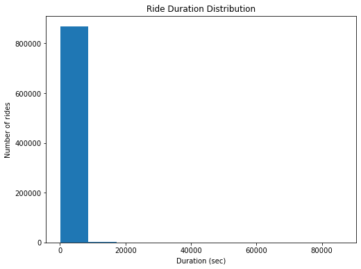

```python
plt.figure(figsize=[8, 6])
plt.hist(data=master, x='duration_sec')
plt.xlabel("Duration (sec)")
plt.ylabel("Number of rides")
plt.title("Ride Duration Distribution")
plt.show()
```

> It looks like most of the rides are under 10,000 seconds. Lets increase the bins size and change the scale of both axis

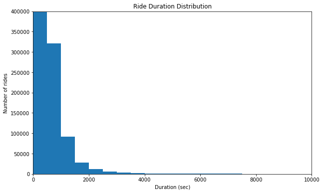

```python
plt.figure(figsize=[10, 6])
bin_edges = np.arange(0, master['duration_sec'].max()+500, 500)
plt.hist(data=master, x='duration_sec', bins=bin_edges)
plt.xlabel("Duration (sec)")
plt.ylabel("Number of rides")
plt.title("Ride Duration Distribution")
plt.axis([0, 10000, 0, 400000]);
```

> There is a long tail in the distribution. Using a log scale should rectify this.

```python
np.log10(master['duration_sec']).describe()
```

```
count    870904.000000
mean          2.733840
std           0.317595
min           1.785330
25%           2.527630
50%           2.729974
75%           2.924279
max           4.935074
Name: duration_sec, dtype: float64
```

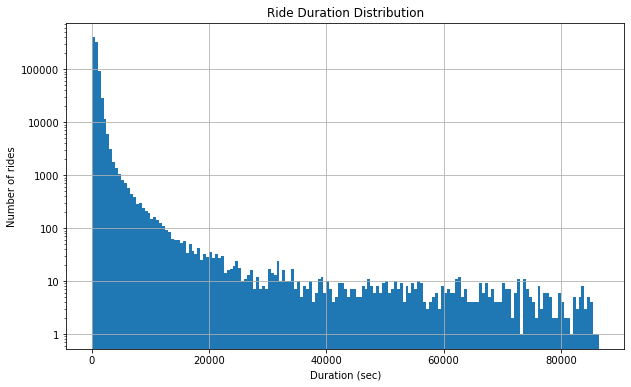

```python
plt.figure(figsize=[10, 6])
bins_edges = 10 ** np.arange(1.79, 4.94 + 0.1, 0.1)
plt.hist(data=master, x='duration_sec', bins=bin_edges)
plt.yscale('log')
plt.yticks([1e0, 1e1, 1e2, 1e3, 1e4, 1e5], [1, 10, 100, 1000, 10000, 100000])
plt.xlabel('Duration (sec)')
plt.ylabel('Number of rides')
plt.title("Ride Duration Distribution")
plt.grid()
plt.show()
```

> After increasing the number of bins and applying the logarithmic scale on the y-axis, it shows that the distribution is right skewed and that majority of the rides have short durations between 0 and 2000 seconds.

Next we look at the distribution of the age of Ford GoBike System customers

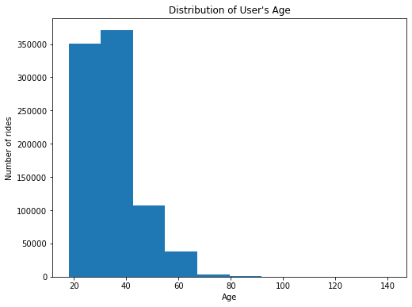

```python
plt.figure(figsize=[8, 6])
plt.hist(data=master, x='age')
plt.xlabel("Age")
plt.ylabel("Number of rides")
plt.title("Distribution of User's Age")
plt.show()
```

> It looks like majority of the customers are between the ages of 20 and 40. The distribution also has a long tail. We should increase the bins size and apply log transformation.

```python
np.log10(master['age']).describe()
```

```
count    870904.000000
mean          1.518895
std           0.114874
min           1.255273
25%           1.431364
50%           1.505150
75%           1.591065
max           2.149219
Name: age, dtype: float64
```

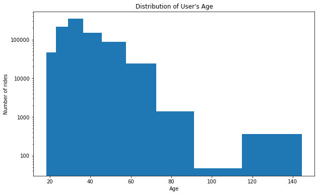

```python
plt.figure(figsize=[10, 6])
bin_edges = 10 ** np.arange(1.26, 2.15+0.1, 0.1)
plt.hist(data=master, x='age', bins=bin_edges)
plt.xlabel("Age")
plt.ylabel("Number of rides")
plt.title("Distribution of User's Age")
plt.yscale('log')
plt.yticks([1e2, 1e3, 1e4, 1e5], [100, 1000, 10000, 100000])

plt.show()
```

> After increasing the bins size and applying log transformation on the y-axis, it looks like majority of Ford GoBike customers are between the ages of 20 and 60 with the peak age at 30. it also looks like some cutomers are over 100 years old. False date of birth information?

Next we look at the distribution of distance

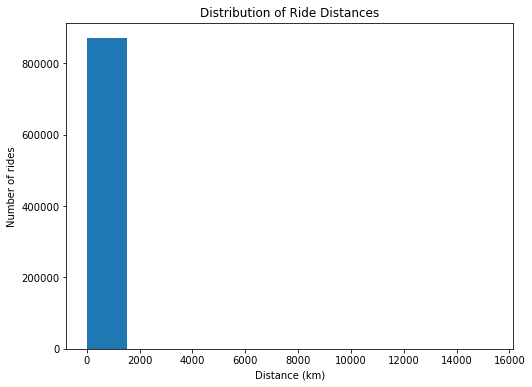

```python
plt.figure(figsize=[8, 6])
plt.hist(data=master, x='distance')
plt.xlabel('Distance (km)')
plt.ylabel('Number of rides')
plt.title("Distribution of Ride Distances")
plt.show()
```

> it looks like most of the rides have short distances. Increasing the bins size and applying log transformation.

```python
np.log10(master['distance']).describe()
```

```
count    8.709040e+05
mean             -inf
std               NaN
min              -inf
25%      1.120910e-02
50%      2.078209e-01
75%      4.018308e-01
max      4.186489e+00
Name: distance, dtype: float64
```

```python
#selecting the trips that have a different start and end station
distance_df = master[master['distance'] > 0]
```

```python
np.log10(distance_df['distance']).describe()
```

```
count    849743.000000
mean          0.211718
std           0.273368
min          -1.793212
25%           0.028464
50%           0.217993
75%           0.407125
max           4.186489
Name: distance, dtype: float64
```

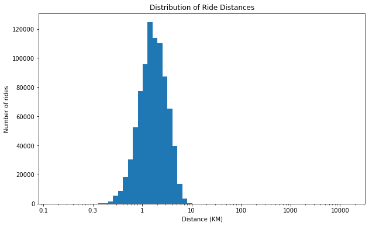

```python
plt.figure(figsize=[10, 6])
bin_edges = 10 ** np.arange(-1.79, 4.19+0.1, 0.1)
plt.hist(data=distance_df, x='distance', bins=bin_edges)
plt.xlabel("Distance (KM)")
plt.ylabel("Number of rides")
plt.title("Distribution of Ride Distances")
plt.xscale('log')
plt.xticks([1e-2, 1e-1, 1e0, 1e1, 1e2, 1e3, 1e4], [0.1, 0.3, 1, 10, 100, 1000, 10000])

plt.show()
```

> After increasing bins size and applying log transformation on the x-axis, we see that majority of the rides are under 10 km with the peak distance traveled for most trips at 1km.

Next we look at the counts of categorical variables in the dataset.

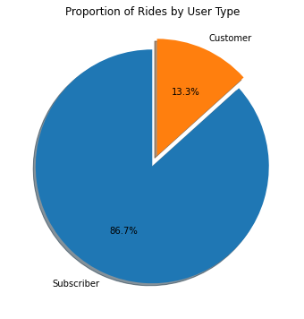

```python
plt.figure(figsize=[8, 6])

label = ['Subscriber', 'Customer']
type_counts = master['user_type'].value_counts()
plt.pie(type_counts, labels=label, autopct='%1.1f%%', explode=[0,0.1], shadow=True, startangle=90)
plt.title('Proportion of Rides by User Type')
plt.show()
```

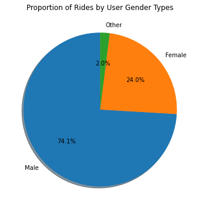

```python
plt.figure(figsize=[8, 6])

label = ['Male', 'Female', 'Other']
gender_counts = master['member_gender'].value_counts()
plt.pie(gender_counts, labels=label, autopct='%1.1f%%', shadow=True, startangle=90)
plt.title('Proportion of Rides by User Gender Types')
plt.show()
```

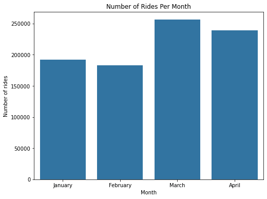

```python
plt.figure(figsize=[8, 6])
base_color = sb.color_palette()[0]

sb.countplot(data=master, x='month', color=base_color)
plt.xlabel("Month")
plt.ylabel("Number of rides")
plt.title("Number of Rides Per Month")
plt.show()
```

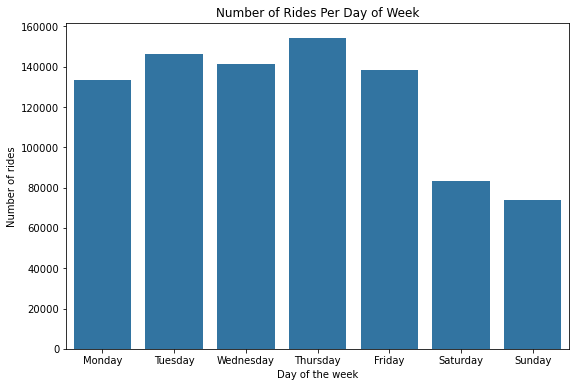

```python
plt.figure(figsize=[9, 6])
sb.countplot(data=master, x='day_of_week', color=base_color)
plt.xlabel("Day of the week")
plt.ylabel("Number of rides")
plt.title("Number of Rides Per Day of Week")
plt.show()
```

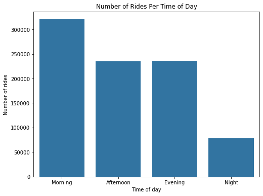

```python
plt.figure(figsize=[8, 6])
sb.countplot(data=master, x='time_of_day', color=base_color)
plt.xlabel("Time of day")
plt.ylabel("Number of rides")
plt.title("Number of Rides Per Time of Day")
plt.show()
```

### Discuss the distribution(s) of your variable(s) of interest. Were there any unusual points? Did you need to perform any transformations?

> Analysis of the `distance` variable showed a right skewed distribution with a long tail and that most of the rides have short distances. Applying a log transformation on the x-axis and increasing the bins size showed that the distance of most rides is between 0.3km and 10km with the peak distance travelled for most rides at 1km.

> The analysis of the `user_type` variable shows that most of Ford GoBike users are Subscribers, 86.7% of them while the remaining 13.3% are Customers.

> The analysis of the `member_gender` variable show that majority of Ford GoBike users are male (74.1%) and 24.0% are female while 2.0% are other (did not specify their gender).

> Of the four months of Ford GoBike systems data analysed, March recorded the highest number of rides closely followed by April and then January and February

> Analysing the `day of week` variable showed that majority of the rides were taken during the week days while the weekends see less trips.

> Analysing the `time_of_day` variable showed that a lot of users take rides during the Morning, followed by Evening and Afternoon. Night's has the lowest number of rides recorded.

### Of the features you investigated, were there any unusual distributions? Did you perform any operations on the data to tidy, adjust, or change the form of the data? If so, why did you do this?

> All the distribution of the three variable `duration_sec`, `age`, `distance` analyzed were highly skewed to the right so log transformation was applied to the y-axis of `duration_sec` and `age` variables and to the x-axis of the `distance` variable.

> The `month`, `day_of_week`, and `time_of_day` variables are all derived variables. They were extracted from the `start_time` variable which is a datetime object.

> The `distance` variable is also a derived variable. It was calculated using the `start station latitude`, `end station latitude`, `start station longitude` and `end station longitude` together with the radius of the earth in kilometres.

> These derived variables were added to the dataset to aid in the analysis of Ford GoBike systems data.

## Bivariate Exploration

> In this section, we will investigate relationships between pairs of variables in our dataset

Let's look at the relationship between month vs duration and month vs distance

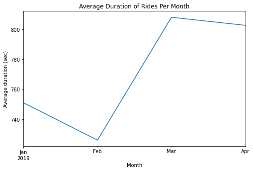

```python
plt.figure(figsize=[8, 5])
master.resample('M', on = 'start_time')['duration_sec'].mean().plot()
plt.xlabel('Month')
plt.ylabel('Average duration (sec)')
plt.title("Average Duration of Rides Per Month")
plt.show()
```

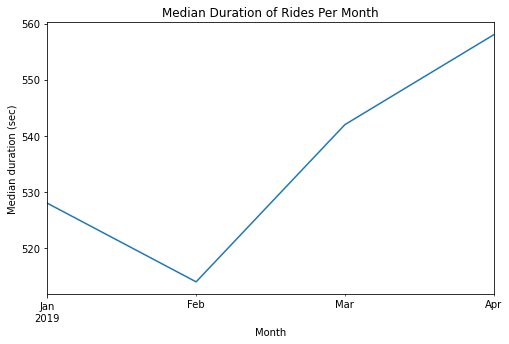

```python
plt.figure(figsize=[8, 5])
master.resample('M', on = 'start_time')['duration_sec'].median().plot()
plt.xlabel('Month')
plt.ylabel('Median duration (sec)')
plt.title("Median Duration of Rides Per Month")
plt.show()
```

> Using the median, we see that duration continued to increase from February to April.

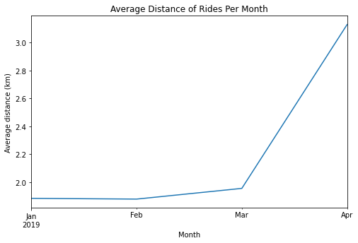

```python
# Plotting the average distance of trips taken from January and April
plt.figure(figsize=[8, 5])
master.resample('M', on = 'start_time')['distance'].mean().plot()
plt.xlabel('Month')
plt.ylabel('Average distance (km)')
plt.title("Average Distance of Rides Per Month")
plt.show()
```

> The average distance travelled in the month of January remained the same with a slight increase between Febraury and March and a Large increase between March and April.

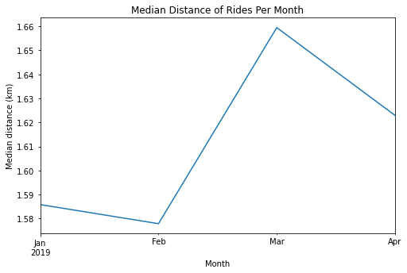

```python
# plotting the median distance which is less susceptible to outliers
plt.figure(figsize=[8, 5])
master.resample('M', on = 'start_time')['distance'].median().plot()
plt.xlabel('Month')
plt.ylabel('Median distance (km)')
plt.title("Median Distance of Rides Per Month")
plt.show()
```

Using the median distance, we see the decline from January to February and a sharp increase from February to March and then a sharp decrease from March to April.

> Let's look at the relationship between duration and distance

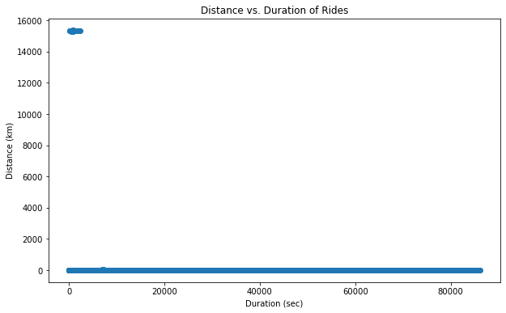

```python
plt.figure(figsize=[10,6])
plt.scatter(data=master, x='duration_sec', y='distance')
plt.xlabel("Duration (sec)")
plt.ylabel("Distance (km)")
plt.title("Distance vs. Duration of Rides")
plt.show()
```

> Due to the extreme values in the distance and duration_sec variables, the relationship between distance and duration_sec is not clear. Put in another way, Most of the trips were short and have a duration between 0 and 2000 seconds and distance between 0.3 and 10 km. Because the dataset contains extreme values of duration_sec such as 80,000 seconds and extreme values of distance up to 16, 000 km, the relationship between duration_sec and distance have been obscured.

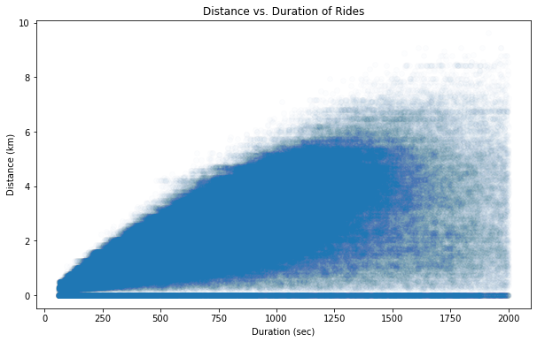

```python
# mask to subset the master dataframe that contains trips with duration <= 2000 seconds and distance <= 10km
mask = (master.distance <= 12) & (master.duration_sec <= 2000)
distance_df = master[mask]
plt.figure(figsize=[10,6])
plt.scatter(data=distance_df, x='duration_sec', y='distance', alpha=0.01)
plt.xlabel("Duration (sec)")
plt.ylabel("Distance (km)")
plt.title("Distance vs. Duration of Rides")
plt.show()
```

> The scatterplot shows that there is a positive correlation between distance and duration_sec. As the distance increases so too does the duration of rides. the distance remained at 0km for those rides with the same start and end stations while the duration differs signifying the lenght of the trip. That is the time it took to complete the ride and return the bike to the station.

> Next we look at the relationship between age and duration

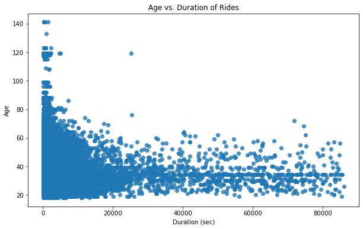

```python
plt.figure(figsize=[10,6])

sb.regplot(data=master, x='duration_sec', y='age', fit_reg=False)
plt.xlabel("Duration (sec)")
plt.ylabel("Age")
plt.title("Age vs. Duration of Rides")
plt.show()
```

> Looks like younger members have a higher duration than older members. Lets see if the plot will become clearer after removing the extreme values of age and duration.

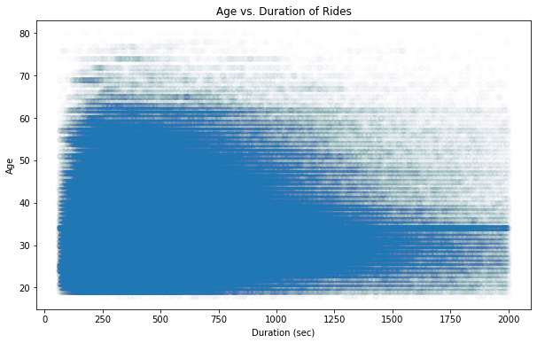

```python
mask = (master.duration_sec <= 2000) & (master.age <= 80)

age_df = master[mask]

plt.figure(figsize=[10,6])

sb.regplot(data=age_df, x='duration_sec', y='age', scatter_kws={'alpha':0.009}, fit_reg=False)
plt.xlabel("Duration (sec)")
plt.ylabel("Age")
plt.title("Age vs. Duration of Rides")
plt.show()
```

> The plots show that majority of Ford GoBike members are between the age of 20 and 50 years with younger members clocking higher durations. Members between the age of 25 and 35 clocked the highest durations.

> Next we look at the relationship between member genders and duration.

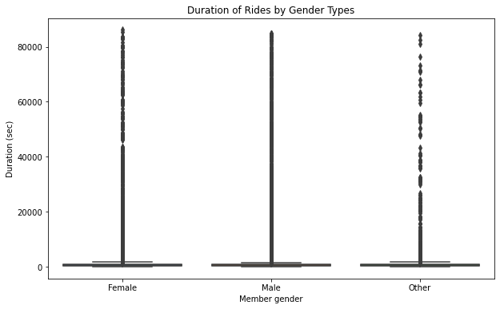

```python
plt.figure(figsize=[10,6])
sb.boxplot(data=master, x='member_gender', y='duration_sec')
plt.xlabel("Member gender")
plt.ylabel("Duration (sec)")
plt.title("Duration of Rides by Gender Types")
plt.show()
```

> The outliers have taken centre stage. Let's remove the outliers and re-plot.

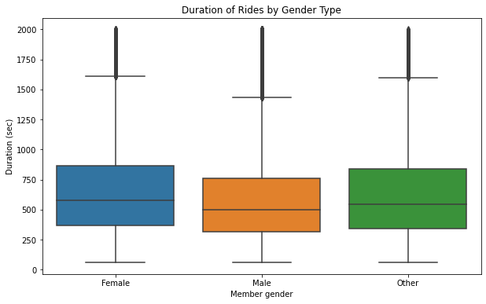

```python
plt.figure(figsize=[10,6])

gender_df = master[master['duration_sec'] <= 2000]

sb.boxplot(data=gender_df, x='member_gender', y='duration_sec')
plt.xlabel("Member gender")
plt.ylabel("Duration (sec)")
plt.title("Duration of Rides by Gender Type")
plt.show()
```

> The plot above shows that Females took longer rides than Other and males. Even though male members are more than females and Other.

> Next we look at the relationship between user type and duration

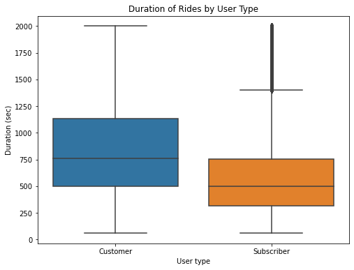

```python
plt.figure(figsize=[8, 6])

user_df = master[master['duration_sec'] <= 2000]

sb.boxplot(data=user_df, x='user_type', y='duration_sec')
plt.xlabel("User type")
plt.ylabel("Duration (sec)")
plt.title("Duration of Rides by User Type")
plt.show()
```

> From the box plot, customers took rides with longer duration than subscribers.

> Next we look at the relationship between time_of_day when trips are taken and member gender.

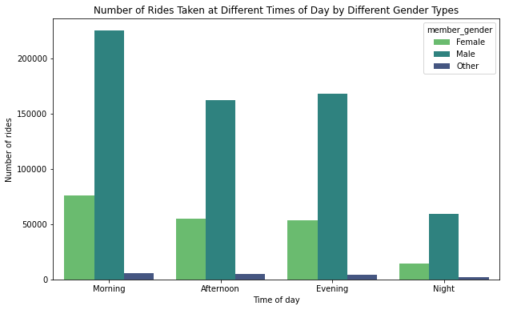

```python
plt.figure(figsize=[10,6])
sb.countplot(data=master, x='time_of_day', hue='member_gender', palette='viridis_r')
plt.xlabel("Time of day")
plt.ylabel("Number of rides")
plt.title("Number of Rides Taken at Different Times of Day by Different Gender Types")
plt.show()
```

### Talk about some of the relationships you observed in this part of the investigation. How did the feature(s) of interest vary with other features in the dataset?

> `Month` vs `Duration` and `Month` vs `Distance`: Using the median value which is less susceptible to outliers to visualize the trends of duration and distance between January to April, we see that there was a decline in the duration and distance of rides taken from January to February and that while duration increased from February to April, distance increased from February to March followed by a sharp decrease between March and April.

> `Duration vs Distance`: After removing the outliers from duration and distance, we observerd that there is a positive correlation between the distance and duration variables and that most of the rides had a duration between 0 and 1500 seconds. We also observed that the distance remained at 0km for those rides with the same start and end stations while the duration varies signifying the lenght of the ride or the time it took for the bike to be returned to the station.

> `Duration vs Age`: After removing the outliers from duration and age, we observed that majority of Ford GoBike members are between the age of 20 and 50 years with younger members clocking the highest durations. Specifically we saw that Members between the age of 25 and 35 clocked the highest durations.

> `Member gender` vs `Duration`: We observed that female members took longer rides than other (unpecified gender) and males. This is the case despite male members having a higher percentage than females.

> `User Type` vs `Duration`: The relationship we observed from the `user_type` and `duration_sec` variables is that cutomers took longer rides than subsribers.

### Did you observe any interesting relationships between the other features (not the main feature(s) of interest)?

> The relationship between `duration` vs `month`, and `distance` vs `month`: while there was a sharp increase in the duration of rides taken between February and April, the distance of rides taken only increased from February to March then a sharp decrease between March and April.

> The relationship between `member gender` and `duration` is interesting. This is because the percentage of rides taken by males is more than that of females and males also have the highest number of outliers.

> The relationship between `user type` and `duration` was also unexpected. This is because customers took longer rides than subscribers despite the fact that the percentage of subscribers is larger than that of customers.

## Multivariate Exploration

> In this section, we will explore the relationship between three or more variables in our dataset.

> Let's start by looking at the relationship between `duration_sec`, `age` and `member_gender`

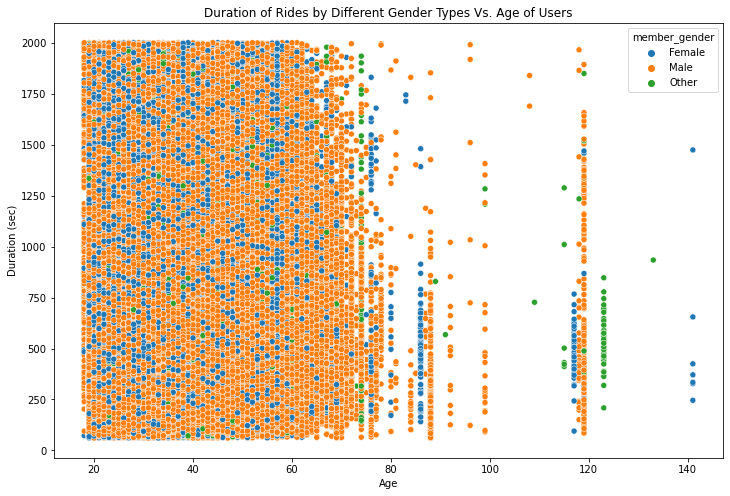

```python
# variable to select only trips without outliers in the duration_sec and distance columns
mask = (master.distance <= 12) & (master.duration_sec <= 2000)
distance_df = master[mask]
plt.figure(figsize=[12,8])
sb.scatterplot(data=distance_df, x='age', y='duration_sec', hue='member_gender')
plt.xlabel("Age")
plt.ylabel("Duration (sec)")
plt.title("Duration of Rides by Different Gender Types Vs. Age of Users")
plt.show()
```

> The plot shows that the age of most members is between 20 and about 80 years and the percentage of males is higher than females and other (unspecified gender). The plot doesn't show the relationship betweeen the three variables clearly. Let's use seaborn's FacetGrid to plot duration vs age for all gender types.

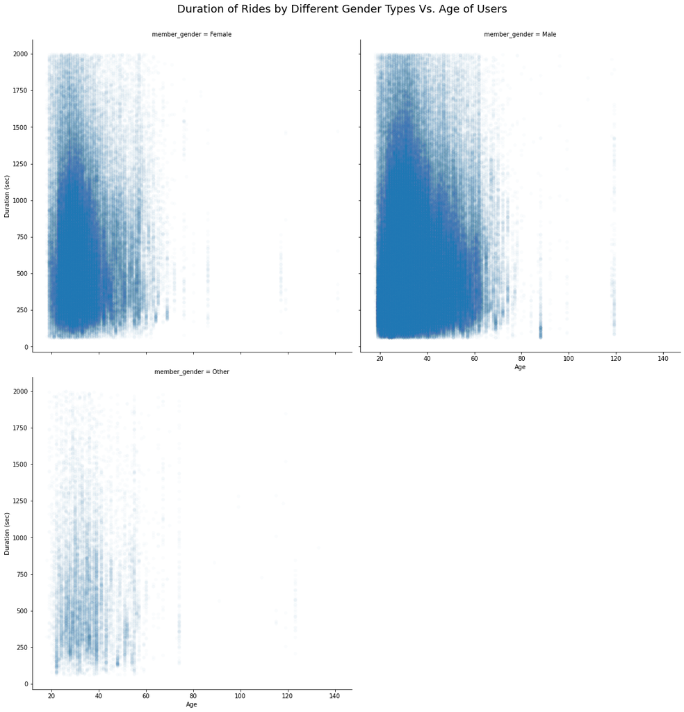

```python
# using seaborn's FacetGrid object to plot duration vs age for all gender types.
g = sb.FacetGrid(data=distance_df, col='member_gender',col_wrap=2, height=8, sharex=True)
g.map(sb.scatterplot, 'age', 'duration_sec', alpha=0.02)
g.set_xlabels("Age")
g.set_ylabels("Duration (sec)")
g.fig.suptitle("Duration of Rides by Different Gender Types Vs. Age of Users", fontsize=18, y=1.03)
plt.show()
for ax in g.axes.flat:
    ax.yaxis.set_major_formatter(lambda y, p: f'{y*1:.2f}')
```

> The plots show that there is high number of female members that are between the age of 20 and 40 that take long duration rides while male members between the age of 20 and 60 years also take long duration ride. It also shows that there is a larger percentage of males that take short duration rides than females. Members with unpecified gender (other) that are between the age of 20 and 40 take rides that have a duration of about 1000 seconds.

> Next we look at the relationship between `duration_sec`, `distance` and `member_gender`

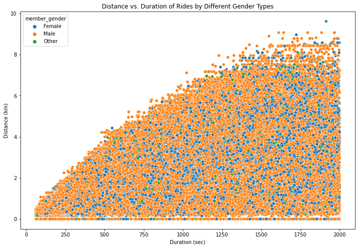

```python
plt.figure(figsize=[12,8])
sb.scatterplot(data=distance_df, x='duration_sec', y='distance', hue='member_gender')
plt.xlabel("Duration (sec)")
plt.ylabel("Distance (km)")
plt.title("Distance vs. Duration of Rides by Different Gender Types")
plt.show()
```

> The plot shows the positive correlation between `distance` and `duration_sec` but fails to include the relationship of `member_gender` clearly.

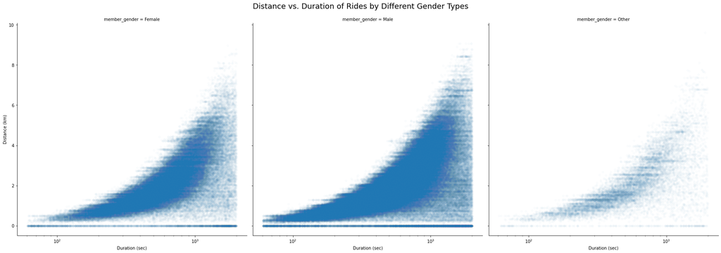

```python
g = sb.FacetGrid(data=distance_df, col='member_gender',col_wrap=3, height=8)
g.map(sb.scatterplot, 'duration_sec', 'distance', alpha=0.02)
g.set(xscale='log')
g.set_xlabels("Duration (sec)")
g.set_ylabels("Distance (km)")
g.fig.suptitle("Distance vs. Duration of Rides by Different Gender Types", fontsize=18, y=1.04)
plt.show()
g.add_legend()
for ax in g.axes.flat:
    ax.xaxis.set_major_formatter(lambda y, p: f'{y*1:.2f}')
```

> The plots show that there is a similar trend for all categories of gender for Ford GoBike members and that the number of males taking short distance rides is larger than that of females and Other (unspecified gender).